# Image Classification using `CIFAR-10` dataset

### Import certain libraries

```python
import numpy as np
import pandas as pd

import os

import matplotlib.pyplot as plt
import seaborn as sns

import tensorflow as tf
from tensorflow.keras import datasets, layers, models
```

```python
### Get the current working directory
os.getcwd()
```

```
'/content'
```

## Download and prepare the `CIFAR-10` dataset

- The CIFAR10 dataset contains **60,000 color images** in `10 classes`, with `6,000 images` in each class.
- Dataset is divided into **50,000 training images** and **10,000 testing** images.
- Classes are mutually exclusive and there is no overlap between them
- There is no overlap between `automobiles` and `trucks`. Truck class contains only `big` trucks

```python
(train_images, train_labels), (test_images, test_labels) = datasets.cifar10.load_data() #loading the CIFAR-10 dataset directly from tf.keras
```

```
Downloading data from https://www.cs.toronto.edu/~kriz/cifar-10-python.tar.gz
170498071/170498071 ━━━━━━━━━━━━━━━━━━━━ 2364s 14us/step
```

```python
train_images.shape
```

```
(50000, 32, 32, 3)
```

```python
test_images.shape
```

```
(10000, 32, 32, 3)
```

### Let us plot one of the `training` images from CIFAR-10 dataset

```python
sample_image_1 = train_images[12]
sample_image_1
```

```
ndarray (32, 32, 3)
```

```
array([[[164, 215, 244],
        [162, 212, 240],
        [162, 212, 240],
        ...,
        [157, 210, 237],
        [153, 208, 235],
        [153, 203, 234]],

       [[168, 218, 245],
        [166, 215, 242],
        [166, 215, 242],
        ...,
        [164, 212, 238],
        [160, 209, 236],
        [158, 205, 235]],

       [[172, 220, 246],
        [170, 217, 243],
        [171, 218, 244],
        ...,
        [168, 212, 238],
        [165, 208, 235],
        [163, 207, 236]],

       ...,

       [[123, 160, 105],
        [117, 154, 102],
        [112, 149,  99],
        ...,
        [117, 136, 100],
        [ 95, 115,  79],
        [120, 149, 100]],

       [[120, 156, 100],
        [116, 151,  99],
        [112, 147,  96],
        ...,
        [126, 149, 110],
        [120, 144, 103],
        [120, 152, 101]],

       [[121, 154,  96],
        [120, 152,  99],
        [116, 148,  97],
        ...,
        [124, 152, 108],
        [124, 154, 107],
        [120, 154, 100]]], dtype=uint8)
```

```python
sample_image_1.shape
```

```
(32, 32, 3)
```

```python
print("Shape of the sample training image:", sample_image_1.shape)
```

```
Shape of the sample training image: (32, 32, 3)
```

```python
### Extract the R, G, B channels separately
R = sample_image_1[:, :, 0] #to extract one of the color channels from a color image --> RED
G = sample_image_1[:, :, 1] #to extract one of the color channels from a color image --> GREEN
B = sample_image_1[:, :, 2] #to extract one of the color channels from a color image --> BLUE
```

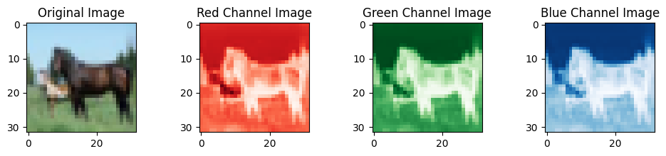

```python
#### Display the original image alogn with `RGB` channels separately
### Setting up the canvas ready
fig, axs = plt.subplots(nrows=1, ncols=4, figsize = (12,2))

### Original Image
axs[0].imshow(sample_image_1)
axs[0].set_title("Original Image")

### Red Channel Image
axs[1].imshow(R, cmap='Reds')
axs[1].set_title("Red Channel Image")

### Green Channel Image
axs[2].imshow(G, cmap='Greens')
axs[2].set_title("Green Channel Image")

### Blue Channel Image
axs[3].imshow(B, cmap='Blues')
axs[3].set_title("Blue Channel Image")

plt.show()
```

### Let us plot a few more but this time with class/label as title

```python
np.unique(train_labels)
```

```
array([0, 1, 2, 3, 4, 5, 6, 7, 8, 9], dtype=uint8)
```

- Class/catgory is `label encoded (LE)`

```python
class_names = ['airplane', 'automobile', 'bird', 'cat', 'deer', 'dog', 'frog', 'horse', 'ship', 'truck']
```

```python
class_names
```

```
['airplane',
 'automobile',
 'bird',
 'cat',
 'deer',
 'dog',
 'frog',
 'horse',
 'ship',
 'truck']
```

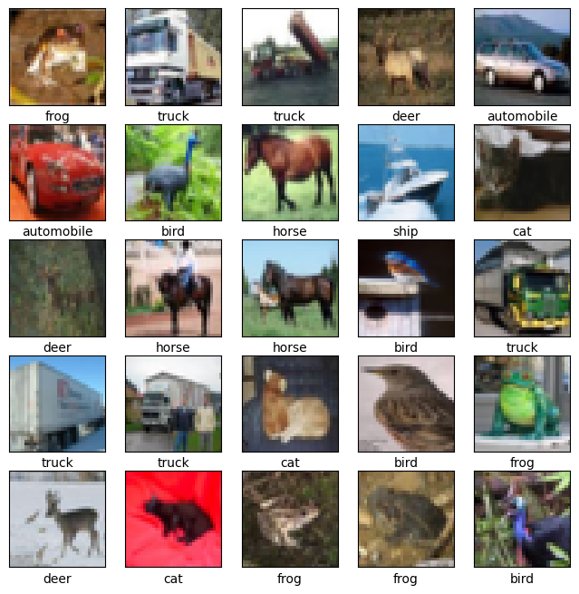

```python
plt.figure(figsize = (8,8))

for i in range(25):
    plt.subplot(5,5,i+1)
    plt.xticks([])
    plt.yticks([])
    plt.grid(False)

    plt.imshow(train_images[i]) #plot the images from training set from 0 to 24 indices
    plt.xlabel(class_names[train_labels[i][0]]) #tagging the class label to the respective class names using class_names list
```

### TASK: Try improvising this code to plot `n random images` from both `training` and `testing` sets respectively

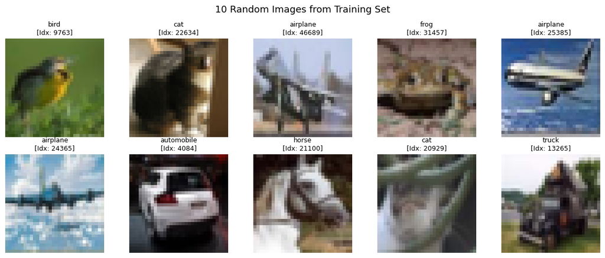

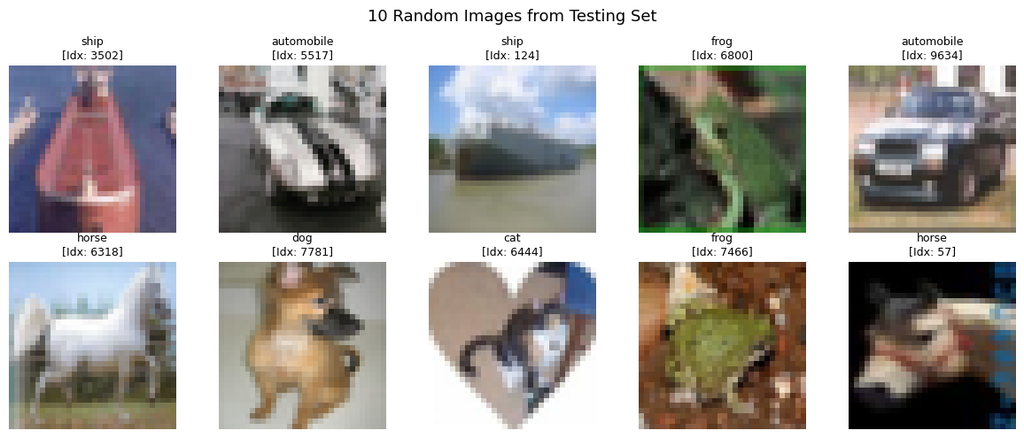

```python
# SOLUTION FOR TASK (Cell 22): Plot n random images with labels from any split
def plot_n_random_images(images, labels, class_names, n=10, split_name='Training'):
    indices = np.random.choice(len(images), size=n, replace=False)
    cols = 5
    rows = (n + cols - 1) // cols
    plt.figure(figsize=(12, rows * 2.5))
    for i, idx in enumerate(indices):
        plt.subplot(rows, cols, i + 1)
        plt.imshow(images[idx])
        plt.title(f'{class_names[labels[idx][0]]}\n[Idx: {idx}]', fontsize=9)
        plt.axis('off')
    plt.suptitle(f'{n} Random Images from {split_name} Set', fontsize=13)
    plt.tight_layout()
    plt.show()

# Demonstration:
plot_n_random_images(train_images, train_labels, class_names, n=10, split_name='Training')
plot_n_random_images(test_images, test_labels, class_names, n=10, split_name='Testing')
```

### Understanding the `convolution` or `filtering` operation

```python
from PIL import Image, ImageChops #read about Pillow library
import requests
from io import BytesIO
```

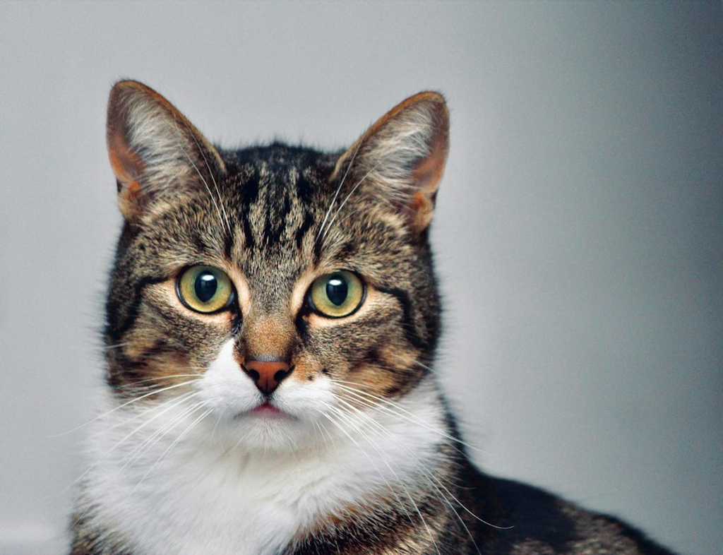

```python
 image_url = 'https://images.unsplash.com/photo-1529778873920-4da4926a72c2?q=80&w=736&auto=format&fit=crop&ixlib=rb-4.1.0&ixid=M3wxMjA3fDB8MHxwaG90by1wYWdlfHx8fGVufDB8fHx8fA%3D%3D'
 image_url = 'https://preview.redd.it/timepass-click-v0-7f08yp0nrcce1.jpg?width=1080&crop=smart&auto=webp&s=68cdc4aa5088ffc54ba952fb9ad7fbe7496be53a'
image_url = 'https://images.unsplash.com/photo-1583795128727-6ec3642408f8?q=80&w=1057&auto=format&fit=crop&ixlib=rb-4.1.0&ixid=M3wxMjA3fDB8MHxwaG90by1wYWdlfHx8fGVufDB8fHx8fA%3D%3D'
response = requests.get(image_url)
img = Image.open(BytesIO(response.content))
display(img)
```

```python
### To get the size of the CAT's image
width, height = img.size
print("Width of the CAT's image:", width, "px")
print("Height of the CAT's image:", height, "px")
```

```
Width of the CAT's image: 1057 px
Height of the CAT's image: 811 px
```

```python
1057*811
```

```
857227
```

```python
### Let us resize the images from its original size to 200px by 200px
img_resized = img.resize((200, 200))
width1, height1 = img_resized.size
print("Width of resized CAT's image:", width1, "px")
print("Height of resized CAT's image:", height1, "px")
```

```
Width of resized CAT's image: 200 px
Height of resized CAT's image: 200 px
```

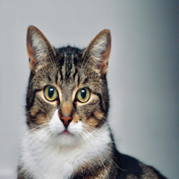

```python
display(img_resized)
```

```
ndarray (200, 200, 3)
```

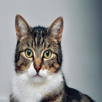

```
array([[[183, 182, 187],
        [182, 182, 187],
        [182, 184, 188],
        ...,
        [ 64,  79,  91],
        [ 63,  77,  86],
        [ 64,  80,  91]],

       [[182, 185, 188],
        [180, 184, 186],
        [180, 186, 188],
        ...,
        [ 65,  79,  89],
        [ 64,  77,  86],
        [ 64,  78,  91]],

       [[181, 185, 188],
        [179, 184, 187],
        [178, 186, 188],
        ...,
        [ 68,  81,  90],
        [ 67,  77,  88],
        [ 64,  77,  92]],

       ...,

       [[177, 180, 184],
        [174, 178, 183],
        [176, 180, 184],
        ...,
        [106, 120, 127],
        [ 99, 118, 123],
        [ 97, 120, 123]],

       [[172, 177, 181],
        [172, 177, 183],
        [175, 179, 183],
        ...,
        [106, 119, 127],
        [100, 119, 124],
        [ 99, 118, 121]],

       [[172, 175, 181],
        [170, 175, 182],
        [172, 176, 182],
        ...,
        [108, 118, 129],
        [103, 118, 126],
        [101, 115, 122]]], dtype=uint8)
```

```python
### Convert the resized image into an array
cat_img_array = np.array(img_resized)
cat_img_array
```

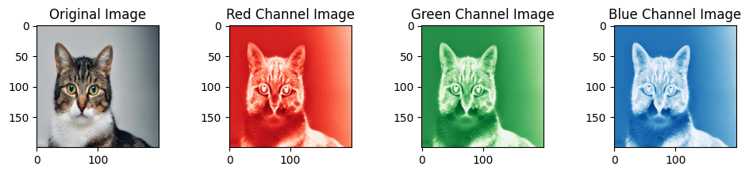

```python
### Extract the R,G,B channels separately
R = cat_img_array[:, :, 0] #to extract one of the color channels from a color image --> RED
G = cat_img_array[:, :, 1] #to extract one of the color channels from a color image --> GREEN
B = cat_img_array[:, :, 2] #to extract one of the color channels from a color image --> BLUE


### Setting up the canvas ready
fig, axs = plt.subplots(nrows=1, ncols=4,figsize=(12,2))

### Original Image
axs[0].imshow(cat_img_array)
axs[0].set_title("Original Image")

### Red Channel Image
axs[1].imshow(R, cmap = 'Reds')
axs[1].set_title("Red Channel Image")

### Green Channel Image
axs[2].imshow(G, cmap = 'Greens')
axs[2].set_title("Green Channel Image")

### Blue Channel Image
axs[3].imshow(B, cmap = 'Blues')
axs[3].set_title("Blue Channel Image")

plt.show()
```